[figure not shown]

GENERALIZED ADDITIVE MODELS

IN FRAUD DETECTION AND

PATTERN RECOGNITION

A Data Science Capstone

Project

by

Grace Allen

Kesi Allen

Sonya Melton

Pingping Zhou

[figure not shown]

INTRODUCTION

INTRODUCTION –PART II

DATA EXPLORATION AND VISUALIZATION

DATA EXPLORATION AND VISUALIZATION –PART II

[figure not shown]

DATA EXPLORATION AND VISUALIZATION –PART1

Dataset Description

🔹What It Is

A synthetic dataset built to mimic real financial transactions

Privacy-safe: no real people’s data used

Hosted on Kaggle

🔹Why We Use It

Train fraud detection models for binary classification tasks

Spot fraud: each transaction labeled as fraud (1) or not fraud (0)

🔹What Makes It Special

Realistic fraud patterns:

oGroups of fraudulent transactions

oSubtle, hard-to-notice anomalies

oOdd user behaviors

Large & diverse records: balances normal vs. rare fraud cases → addresses class imbalance.

[figure not shown]

DATA EXPLORATION AND VISUALIZATION –PART1

Key Characteristics

🔹What's Inside

•50,000 Rows: A good amount of data to work with.

•Two Labels: Every transaction is marked as either:

o1 = Fraud

o0 = Not Fraud

🔹Data Features-- 21 features across three categories:

•Numbers: Like transaction amounts, risk scores, account balances.

•Categories: Transaction types (payment, transfer, withdrawal), device types, merchant

categories.

•Time Data: When transactions happened (time, day) and their sequence.

🔹Label Distribution

•Behavioral Realism: Includes unusual spending, behavioral signals, and high-risk profiles.

•Modeling flexibility: supports interpretable (GAMs, logistic regression) or high-performance

(XGBoost) approaches

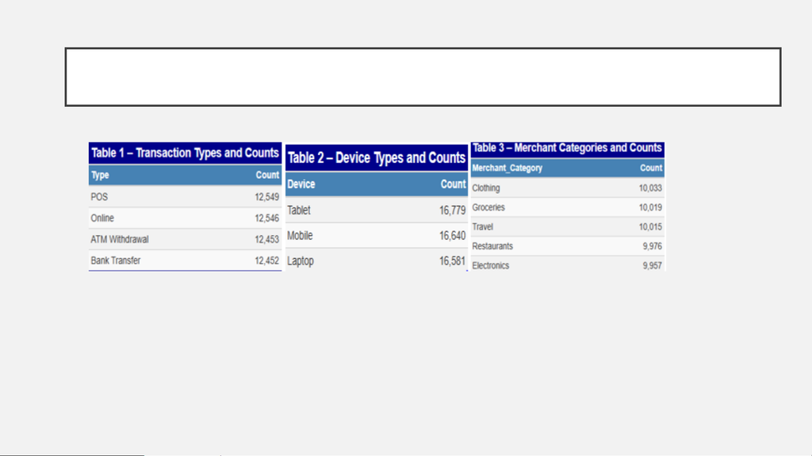

DATA EXPLORATION AND VISUALIZATION –PART11

Visualizations

The charts (including Tables 1, 2, and 3) show that all categories in the dataset —

transaction types, device types, and merchant groups —are almost perfectly

balanced. Each transaction type has about 12,500 cases, each device type around

16,600–16,800, and each merchant category close to 10,000. This even distribution

makes it simple to compare counts and spot patterns. Generalized Additive Models

(GAMs) are still a strong choice because they can handle both numbers and

categories, and capture complex, nonlinear relationships in the data.

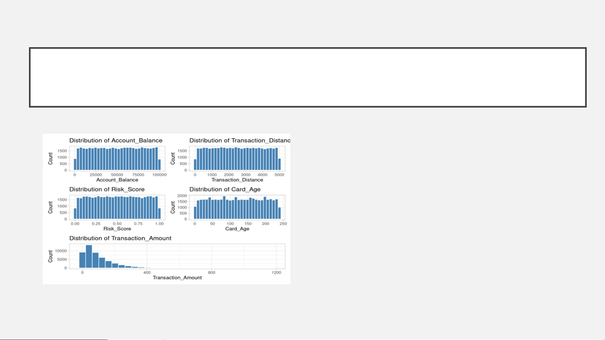

DATA EXPLORATION AND VISUALIZATION –PART11

•Distribution of Variables

Figure 1. Histograms show key variables

used in fraud detection. Most features—

Account_Balance, Transaction_Distance,

Risk_Score, and Card_Age—appear

uniformly distributed, supporting nonlinear

modeling such as GAM.

Transaction_Amount is strongly right-

skewed, with many small transactions and a

few large outliers, indicating that extreme

amounts may signal potential fraud. This

skewness suggests that transformations

(e.g., log-scale) or nonlinear models like

GAM can better capture fraud patterns

and improve prediction accuracy.

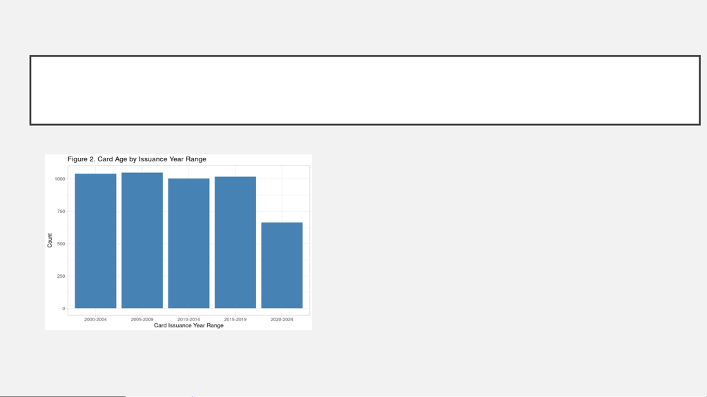

DATA EXPLORATION AND VISUALIZATION –PART11

features may be outdated, while newer cards

may have different usage patterns, like more

digital transactions. These differences suggest

that fraud risk changes with card age, and

models like GAM can help capture those

patterns.

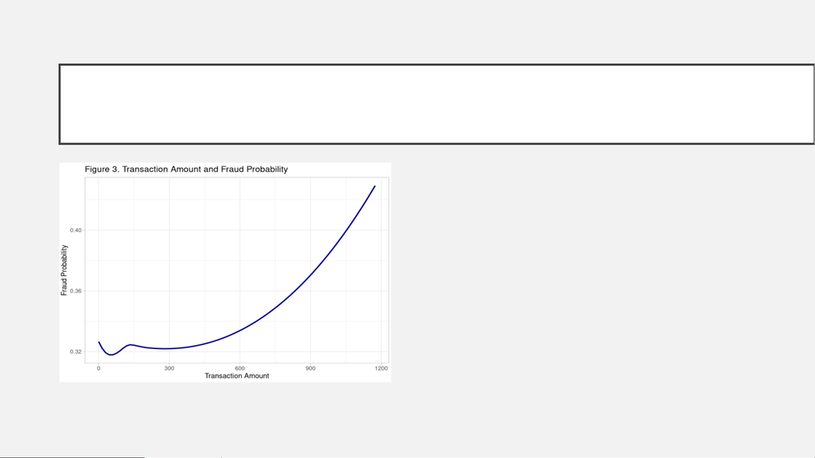

DATA EXPLORATION AND VISUALIZATION –PART11

•Figure 3 shows that fraud

probability changes in a nonlinear

way with transaction amount.

Small payments usually have low

risk, while very large amounts show

higher risk. This makes transaction

amount a key predictor and

shows why GAMs are useful —

they can flexibly capture these

curved patterns.

MODELING AND RESULTS

MODELING AND RESULTS –PART II

CONCLUSION

CONCLUSION –PART II